# A TIME SERIES INVESTIGATION OF HARMFUL AIR POLLUTANTS CONCENTRATIONS IN BERLIN

## By Subhamathi Thiruvenkatam

### 2023-03-09

# Introduction

## General Background:

> Air pollution is a major environmental issue in Germany, and the country has taken several measures to monitor and reduce its air pollution levels. Ozone (O3), nitrogen dioxide (NO2), and nitrogen oxide (NO) are some of the important air pollutants that contribute majorly towards the pollution sector. NO2 is a toxic gas that is largely released by diesel automobiles and is likely to cause health problems related to heart and lung disorders. Vehicles and power plants both emit NO, which is a precursor to NO2. O3 is a secondary pollutant that can destroy plant and animal life as well as cause respiratory issues.Monitoring for air pollution levels helps in locating the sources of the pollution, such as manufacturing facilities, power plants, and vehicles. These sources can be controlled and their emissions can be decreased using this knowledge.Germany has implemented various initiatives in the recent years to control the air pollution and improve the air quality

## Aim and Objective:

> The main aim of this research paper is to monitor Berlin’s air pollution levels and analyse the changes in their patterns with the help of a time series plot. The air pollution levels of the three main air pollutants , NO2,NO,03 are monitored for this study.The hypotheses is taken as the air pollutant NO2 is below the threshold set and the three pollutants are correlated to each other.

# Study Area:

> Germany’s capital and largest city, Berlin, is situated in the northeastern region of the nation. The city, which has a population of over 3.7 million, is renowned for its rich cultural past, and diverse neighbourhoods.Berlin is a significant metropolitan center that serves as a focus for commerce and transportation, resulting in higher levels of air pollution. Berlin is an important area to study the air pollutants characteristics as it is rich in socio-economic activities, population and industrial sectors.

# Datasets Used:

> 1. The annual mean NO2 data for Berlin
> 2. The annual mean O3 data for Berlin
> 3. The annual mean NO data for Berlin

## Data Source:

> https://www.eea.europa.eu/data-and-maps/data/aqereporting-9

# Methodology:

## Libraries Used:

> 1.tidyverse for tiding up the data

> 2.lubridate for formatting the data

> 3.readr for reading csv files

> 4.ggplot2 for data visualization

> 5.reshape2 for melting the correlation matrix

> 6.dplyr for data manipulation

> 7.corrplot for correlation plots

## Method:

> The research starts with preparing the data and importing the data using the read.csv() function.Since I am planned to analyse the data from a single station , the data imported is then filtered to contain only air pollution levels from the station Berlin Neukolln which has 10 years data for all three pollutants. The data is imported in the same way as for NO2,03,NO. The tidyverse library along with ggplot() is used to plot the location of the station on the Berlin city The 10 years data for NO2 is binded into a single file df1, for 03 and NO the same process is repeated using the bind_rows() function All the air pollutants data is binded into one for the final analysis Using ggplot() the air pollutants levels across the Years are plotted as a line graph and all the plots are combined into a single grid The correlation matrix is created for these pollutants and displayed using a heatmap indicating their correlation coefficients using ggplot() and melt()

# Data preparation:

```r
library(tidyverse)
library(lubridate)
```

```r
library(readr)
library(ggplot2)
library(dplyr)
library(corrplot)
library(ggplot2)
library(reshape2)
#Data for NO2
data2010 <- read.csv("C:/Users/subhu/Desktop/AOSD/New folder/berlin no2/2010/b2010.csv")
d10 <- data2010[data2010$Air.Quality.Station.Name == "Berlin Neukolln",]
data2011 <- read.csv("C:/Users/subhu/Desktop/AOSD/New folder/berlin no2/2011/b2011.csv")
d11 <- data2011[data2011$Air.Quality.Station.Name == "Berlin Neukolln",]
data2012 <- read.csv("C:/Users/subhu/Desktop/AOSD/New folder/berlin no2/2012/b2012.csv")
d12 <- data2012[data2012$Air.Quality.Station.Name == "Berlin Neukolln",]
data2013 <- read.csv("C:/Users/subhu/Desktop/AOSD/New folder/berlin no2/2013/b2013.csv")
d13 <- data2013[data2013$Air.Quality.Station.Name == "Berlin Neukolln",]
data2014 <- read.csv("C:/Users/subhu/Desktop/AOSD/New folder/berlin no2/2014/b2014.csv")
d14 <- data2014[data2014$Air.Quality.Station.Name == "Berlin Neukolln",]
data2015 <- read.csv("C:/Users/subhu/Desktop/AOSD/New folder/berlin no2/2015/b2015.csv")
d15 <- data2015[data2015$Air.Quality.Station.Name == "Berlin Neukolln",]
data2016 <- read.csv("C:/Users/subhu/Desktop/AOSD/New folder/berlin no2/2016/b2016.csv")
d16 <- data2016[data2016$Air.Quality.Station.Name == "Berlin Neukolln",]
data2017 <- read.csv("C:/Users/subhu/Desktop/AOSD/New folder/berlin no2/2017/b2017.csv")
d17 <- data2017[data2017$Air.Quality.Station.Name == "Berlin Neukolln",]
data2018 <- read.csv("C:/Users/subhu/Desktop/AOSD/New folder/berlin no2/2018/b2018.csv")
d18 <- data2018[data2018$Air.Quality.Station.Name == "Berlin Neukolln",]
data2019 <- read.csv("C:/Users/subhu/Desktop/AOSD/New folder/berlin no2/2019/b2019.csv")
d19 <- data2019[data2019$Air.Quality.Station.Name == "Berlin Neukolln",]
data2020 <- read.csv("C:/Users/subhu/Desktop/AOSD/New folder/berlin no2/2020/b2020.csv")
d20 <- data2020[data2020$Air.Quality.Station.Name == "Berlin Neukolln",]



#Data for O3
O3_2010 <- read.csv("C:/Users/subhu/Desktop/AOSD/New folder/berlin no2/2010/O3_10.csv")
o10 <- O3_2010[O3_2010$Air.Quality.Station.Name == "Berlin Neukolln",]
O3_2011 <- read.csv("C:/Users/subhu/Desktop/AOSD/New folder/berlin no2/2011/O3_11.csv")
o11 <- O3_2011[O3_2011$Air.Quality.Station.Name == "Berlin Neukolln",]
O3_2012 <- read.csv("C:/Users/subhu/Desktop/AOSD/New folder/berlin no2/2012/O3_12.csv")
o12 <- O3_2012[O3_2012$Air.Quality.Station.Name == "Berlin Neukolln",]
O3_2013 <- read.csv("C:/Users/subhu/Desktop/AOSD/New folder/berlin no2/2013/O3_13.csv")
o13 <- O3_2013[O3_2012$Air.Quality.Station.Name == "Berlin Neukolln",]
O3_2014 <- read.csv("C:/Users/subhu/Desktop/AOSD/New folder/berlin no2/2014/O3_14.csv")
o14 <- O3_2014[O3_2014$Air.Quality.Station.Name == "Berlin Neukolln",]
O3_2015 <- read.csv("C:/Users/subhu/Desktop/AOSD/New folder/berlin no2/2015/O3_15.csv")
o15 <- O3_2015[O3_2015$Air.Quality.Station.Name == "Berlin Neukolln",]
O3_2016 <- read.csv("C:/Users/subhu/Desktop/AOSD/New folder/berlin no2/2016/O3_16.csv")
o16 <- O3_2016[O3_2016$Air.Quality.Station.Name == "Berlin Neukolln",]
O3_2017 <- read.csv("C:/Users/subhu/Desktop/AOSD/New folder/berlin no2/2017/O3_17.csv")
o17 <- O3_2017[O3_2017$Air.Quality.Station.Name == "Berlin Neukolln",]
O3_2018 <- read.csv("C:/Users/subhu/Desktop/AOSD/New folder/berlin no2/2018/O3_18.csv")
o18 <- O3_2018[O3_2018$Air.Quality.Station.Name == "Berlin Neukolln",]
O3_2019 <- read.csv("C:/Users/subhu/Desktop/AOSD/New folder/berlin no2/2019/O3_19.csv")
o19 <- O3_2019[O3_2019$Air.Quality.Station.Name == "Berlin Neukolln",]
O3_2020 <- read.csv("C:/Users/subhu/Desktop/AOSD/New folder/berlin no2/2020/O3_20.csv")
o20 <- O3_2020[O3_2020$Air.Quality.Station.Name == "Berlin Neukolln",]




#Data for NO
NO_2010 <- read.csv("C:/Users/subhu/Desktop/AOSD/New folder/berlin no2/2010/NO_10.csv")
NO10 <- NO_2010[NO_2010$Air.Quality.Station.Name == "Berlin Neukolln",]
NO_2011 <- read.csv("C:/Users/subhu/Desktop/AOSD/New folder/berlin no2/2011/NO_11.csv")
NO11 <- NO_2011[NO_2011$Air.Quality.Station.Name == "Berlin Neukolln",]
NO_2012 <- read.csv("C:/Users/subhu/Desktop/AOSD/New folder/berlin no2/2012/NO_12.csv")
NO12 <- NO_2012[NO_2012$Air.Quality.Station.Name == "Berlin Neukolln",]
NO_2013 <- read.csv("C:/Users/subhu/Desktop/AOSD/New folder/berlin no2/2013/NO_13.csv")
NO13 <- NO_2013[NO_2012$Air.Quality.Station.Name == "Berlin Neukolln",]
NO_2014 <- read.csv("C:/Users/subhu/Desktop/AOSD/New folder/berlin no2/2014/NO_14.csv")
NO14 <- NO_2014[NO_2014$Air.Quality.Station.Name == "Berlin Neukolln",]
NO_2015 <- read.csv("C:/Users/subhu/Desktop/AOSD/New folder/berlin no2/2015/NO_15.csv")
NO15 <- NO_2015[NO_2015$Air.Quality.Station.Name == "Berlin Neukolln",]
NO_2016 <- read.csv("C:/Users/subhu/Desktop/AOSD/New folder/berlin no2/2016/NO_16.csv")
NO16 <- NO_2016[NO_2016$Air.Quality.Station.Name == "Berlin Neukolln",]
NO_2017 <- read.csv("C:/Users/subhu/Desktop/AOSD/New folder/berlin no2/2017/NO_17.csv")
NO17 <- NO_2017[NO_2017$Air.Quality.Station.Name == "Berlin Neukolln",]
NO_2018 <- read.csv("C:/Users/subhu/Desktop/AOSD/New folder/berlin no2/2018/NO_18.csv")
NO18 <- NO_2018[NO_2018$Air.Quality.Station.Name == "Berlin Neukolln",]
NO_2019 <- read.csv("C:/Users/subhu/Desktop/AOSD/New folder/berlin no2/2019/NO_19.csv")
NO19 <- NO_2019[NO_2019$Air.Quality.Station.Name == "Berlin Neukolln",]
NO_2020 <- read.csv("C:/Users/subhu/Desktop/AOSD/New folder/berlin no2/2020/NO_20.csv")
NO20 <- NO_2020[NO_2020$Air.Quality.Station.Name == "Berlin Neukolln",]
```

### Binding all the NO2 data

```r
df1 <- bind_rows(d10, d11, d12, d13, d14, d15, d16, d17, d18, d19, d20)
Nitrogen_dioxide <- df1$Air.Pollution.Level
df1
```

```
##    Country Air.Quality.Network Air.Quality.Network.Name
## 1  Germany           NET.DE_BE           Efthalia Nulis
## 2  Germany           NET.DE_BE           Efthalia Nulis
## 3  Germany           NET.DE_BE           Efthalia Nulis
## 4  Germany           NET.DE_BE        Dr. Katja Grunnow
## 5  Germany           NET.DE_BE        Dr. Katja Grunnow
## 6  Germany           NET.DE_BE        Dr. Katja Grunnow
## 7  Germany           NET.DE_BE        Dr. Katja Grunnow
## 8  Germany           NET.DE_BE        Dr. Katja Grunnow
## 9  Germany           NET.DE_BE        Dr. Katja Grunnow
## 10 Germany           NET.DE_BE        Dr. Katja Grunnow
## 11 Germany           NET.DE_BE        Dr. Katja Grunnow
##    Air.Quality.Station.EoI.Code Air.Quality.Station.Name
## 1                       DEBE034          Berlin Neukolln
## 2                       DEBE034          Berlin Neukolln
```

[output cut: 117 more lines]

### Binding all the O3 Data

```r
O3 <- bind_rows(o10, o11, o12, o13, o14, o15, o16, o17, o18, o19, o20)
Ozone <- O3$Air.Pollution.Level
O3
```

```
##    Country Air.Quality.Network Air.Quality.Network.Name
## 1  Germany           NET.DE_BE           Efthalia Nulis
## 2  Germany           NET.DE_BE           Efthalia Nulis
## 3  Germany           NET.DE_BE           Efthalia Nulis
## 4  Germany           NET.DE_BE        Dr. Katja Grunnow
## 5  Germany           NET.DE_BE        Dr. Katja Grunnow
## 6  Germany           NET.DE_BE        Dr. Katja Grunnow
## 7  Germany           NET.DE_BE        Dr. Katja Grunnow
## 8  Germany           NET.DE_BE        Dr. Katja Grunnow
## 9  Germany           NET.DE_BE        Dr. Katja Grunnow
## 10 Germany           NET.DE_BE        Dr. Katja Grunnow
## 11 Germany           NET.DE_BE        Dr. Katja Grunnow
##    Air.Quality.Station.EoI.Code Air.Quality.Station.Name
## 1                       DEBE034          Berlin Neukolln
## 2                       DEBE034          Berlin Neukolln
```

[output cut: 117 more lines]

### Binding all the NO data

```r
NO <- bind_rows(NO10, NO11, NO12, NO13, NO14, NO15, NO16, NO17, NO18, NO19, NO20)
Nitrogen_Monoxide <- NO$Air.Pollution.Level
NO
```

```
##    Country Air.Quality.Network Air.Quality.Network.Name
## 1  Germany           NET.DE_BE           Efthalia Nulis
## 2  Germany           NET.DE_BE           Efthalia Nulis
## 3  Germany           NET.DE_BE           Efthalia Nulis
## 4  Germany           NET.DE_BE        Dr. Katja Grunnow
## 5  Germany           NET.DE_BE        Dr. Katja Grunnow
## 6  Germany           NET.DE_BE        Dr. Katja Grunnow
## 7  Germany           NET.DE_BE        Dr. Katja Grunnow
## 8  Germany           NET.DE_BE        Dr. Katja Grunnow
## 9  Germany           NET.DE_BE        Dr. Katja Grunnow
## 10 Germany           NET.DE_BE        Dr. Katja Grunnow
## 11 Germany           NET.DE_BE        Dr. Katja Grunnow
##    Air.Quality.Station.EoI.Code Air.Quality.Station.Name
## 1                       DEBE034          Berlin Neukolln
## 2                       DEBE034          Berlin Neukolln
```

[output cut: 117 more lines]

### Combining all the Air pollutants data

```r
All <- bind_rows(df1,O3,NO)
All
```

```
##    Country Air.Quality.Network Air.Quality.Network.Name
## 1  Germany           NET.DE_BE           Efthalia Nulis
## 2  Germany           NET.DE_BE           Efthalia Nulis
## 3  Germany           NET.DE_BE           Efthalia Nulis
## 4  Germany           NET.DE_BE        Dr. Katja Grunnow
## 5  Germany           NET.DE_BE        Dr. Katja Grunnow
## 6  Germany           NET.DE_BE        Dr. Katja Grunnow
## 7  Germany           NET.DE_BE        Dr. Katja Grunnow
## 8  Germany           NET.DE_BE        Dr. Katja Grunnow
## 9  Germany           NET.DE_BE        Dr. Katja Grunnow
## 10 Germany           NET.DE_BE        Dr. Katja Grunnow
## 11 Germany           NET.DE_BE        Dr. Katja Grunnow
## 12 Germany           NET.DE_BE           Efthalia Nulis
## 13 Germany           NET.DE_BE           Efthalia Nulis
## 14 Germany           NET.DE_BE           Efthalia Nulis
```

[output cut: 359 more lines]

### Plotting the station chosen

```r
library(tidyverse) |> suppressPackageStartupMessages()
library(sf)
```

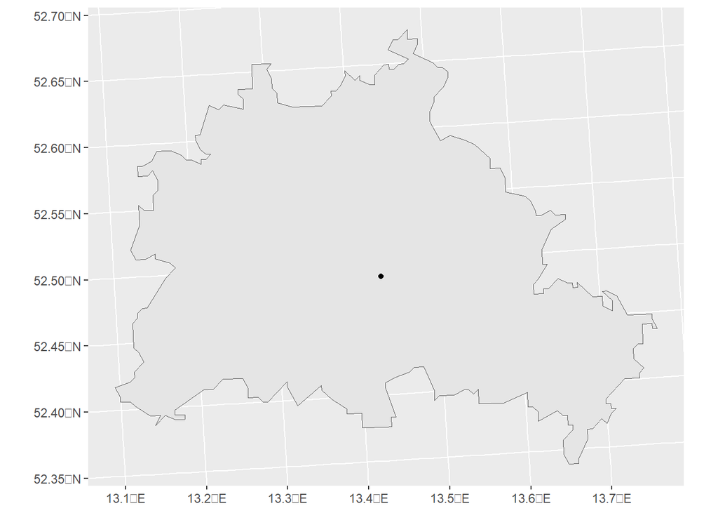

```r
crs <- st_crs("EPSG:32632")
st_as_sf(d12, crs = "OGC:CRS84", coords =
           c("Longitude", "Latitude")) |>
  st_transform(crs) -> no2.sf

read_sf("C:/Users/subhu/Desktop/AOSD/New folder/Berlin/Berlin_city.shp") |> st_transform(crs) -> de


ggplot() + geom_sf(data = de) +
  geom_sf(data = no2.sf)
```

### NO2 data

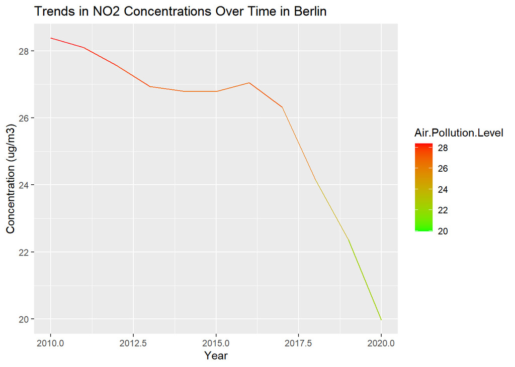

```r
# Visualizing the plot for NO2
options(repr.plot.width = 16, repr.plot.height = 6)

ggplot(data = df1, aes(x = Year, y = Air.Pollution.Level, color = Air.Pollution.Level)) +
  geom_line() +
  scale_color_gradient(low = "green", high = "red") +
  labs(x = "Year", y = "Concentration (ug/m3)", title="Trends in NO2 Concentrations Over Time in Berlin ")
```

> The trend line shows a gradual decline in NO2 levels from 2010 to 2016 but a steep decline from 2016 till 2020. This may account to the taken by the Government to reduce air pollution by electrifying transportation and retrofitting diesel buses.These actions maybe the influence of the ” Immediate Action Programme for Clean Air ” that ran from 2017 to 2020.

### Ozone data

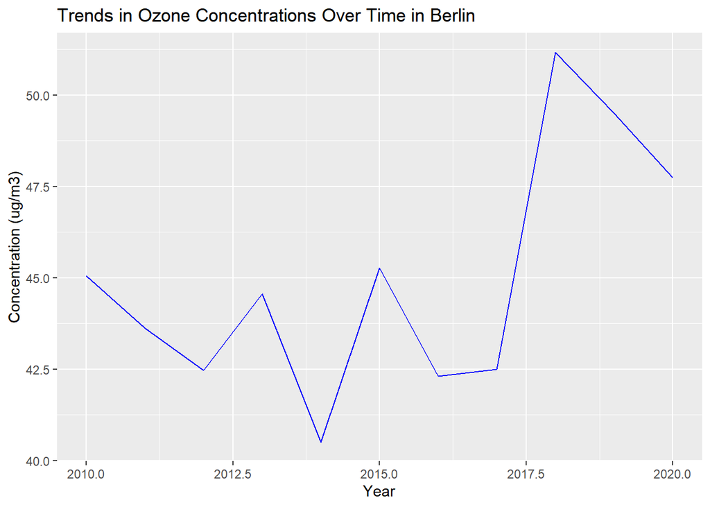

```r
# Visualizing the plot for O3
ggplot(data = O3, aes(x = Year, y = Air.Pollution.Level)) +
  geom_line(color="Blue") +
  labs(x = "Year", y = "Concentration (ug/m3)",title="Trends in Ozone Concentrations Over Time in Berlin ")
```

> Unlike Particulate matter and Nitrogen dioxide , ozone is not emitted directly but formed from NO and organic compounds. Solar radiation is also a main reason for this. Thus when there are long term high pressure summer days, ozone can be stored in the lower layers of the atmosphere leading to its heavy concentration. Therefore the cause for the variation of the levels throughtout the period maybe due to the weather conditions.